# Bellabeat Wellness Analysis

Seema Chavesta

2025-12-15

## Ask: Business Task

The objective of this analysis is to identify trends in smart device usage using Fitbit fitness tracker data and apply these insights to Bellabeat products in order to inform data-driven marketing strategies.

Key questions: - What are trends in smart device usage? - How could these trends apply to Bellabeat customers? - How could these trends influence Bellabeat marketing strategy?

## Prepare: Data Source

This analysis uses the **FitBit Fitness Tracker Data** (CC0: Public Domain), made available via Kaggle by Mobius.

- Daily activity data (steps, calories, activity intensity)
- Daily sleep data (minutes asleep, time in bed)
- Data collected from 30 Fitbit users between April–May 2016

Only daily-level datasets were used to focus on high-level behavioral trends.

## Process and Data Cleaning

```r
library(tidyverse)
library(lubridate)
library(janitor)
```

### Importing the data

```r
daily_activity <- read_csv("raw_data/dailyActivity_merged.csv") %>%
  clean_names() %>%
  mutate(activity_date = mdy(activity_date))
sleep_day <- read_csv("raw_data/sleepDay_merged.csv") %>%
  clean_names() %>%
  mutate(
    sleep_day = mdy_hms(sleep_day),
    sleep_date = as.Date(sleep_day)
  )
```

The datasets were cleaned by: - Standardizing column names - Converting date fields to proper date formats - Removing unnecessary columns for analysis

## Analyze: Smart Device Usage Trends

```r
daily_summary <- daily_activity %>%
  mutate(
    weekday = wday(activity_date, label = TRUE),
    total_active_minutes =
      lightly_active_minutes + fairly_active_minutes + very_active_minutes
  )
```

### Visualization 1: Steps by weekday

### Average Steps by Day of Week

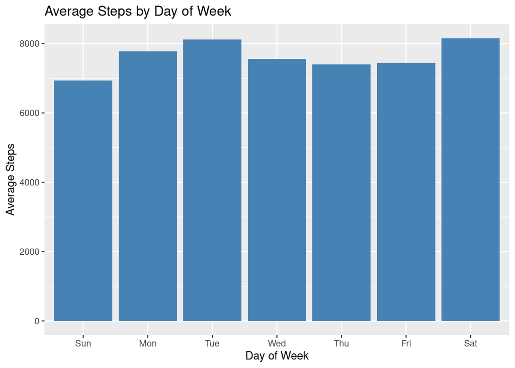

```r
daily_summary %>%
  group_by(weekday) %>%
  summarise(avg_steps = mean(total_steps, na.rm = TRUE)) %>%
  ggplot(aes(x = weekday, y = avg_steps)) +
  geom_col(fill = "steelblue") +
  labs(
    title = "Average Steps by Day of Week",
    x = "Day of Week",
    y = "Average Steps"
  )
```

Users tend to be more active on certain weekdays, indicating consistent weekly behavior patterns in smart device usage

## Sleep and Activity Relationship

```r
sleep_clean <- sleep_day %>%
  select(id, sleep_date, total_minutes_asleep, total_time_in_bed)

sleep_activity <- daily_summary %>%
  inner_join(
    sleep_clean,
    by = c("id" = "id", "activity_date" = "sleep_date")
  ) %>%
  mutate(sleep_efficiency = total_minutes_asleep / total_time_in_bed)
```

### Visualization 2: Sleep efficiency distribution

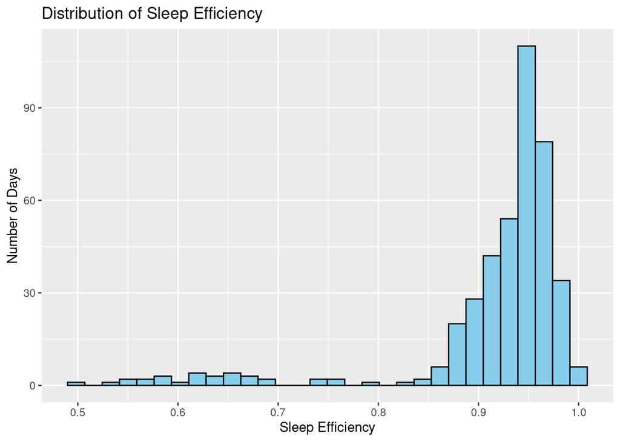

```r
ggplot(sleep_activity, aes(x = sleep_efficiency)) +
  geom_histogram(bins = 30, fill = "skyblue", color = "black") +
  labs(
    title = "Distribution of Sleep Efficiency",
    x = "Sleep Efficiency",
    y = "Number of Days"
  )
```

Most users demonstrate high sleep efficiency, though variability exists, suggesting opportunities for personalized sleep insights.

## Act: Marketing Recommendations

1. **Promote Sleep Quality Features**
   - Emphasize sleep efficiency insights within the Bellabeat app.
   - Encourage consistent sleep routines using smart notifications.
2. **Encourage Light, Sustainable Activity**
   - Target highly sedentary users with gentle movement reminders.
   - Position Bellabeat as a habit-building wellness companion.
3. **Highlight Holistic Wellness**
   - Market Bellabeat as a balance of activity, rest, and mindfulness.
   - Align messaging with long-term health rather than extreme fitness.